# Articles for Deletion — what the discussions look like

This notebook is analysis only. Loading data + any repairs (e.g., backfill API collections of missing data or pages that turned out to be redirects to a full discussion) live in `afd_load.py`. The working notebooks to figure out issues in collected data are: `afd_case_descriptives.ipynb` and `afd_case_descriptives_1.ipynb`

## Groups

We split the deletion cases into a few subsets:

| group | meaning |
| --- | --- |
| `gone` | the article does not exist today |
| `sample` | the 37k study set — surviving, 2007–2022, article ≥30 days old at nomination, cleared the rough match |
| `surviving_nonsample` | survived, not in the sample |
| `surviving` | the union of the last two — a reference line in the figures, **not** a fourth group |

## Note

**A discussion is measured over its first 30 days.** 98%+ of human edits land inside that window; what follows is almost entirely archival bot activity. Measures named `*_days` or `n_*` are window-bounded unless stated.

**"Surviving" means the page exists, not that the article ended in a keep decision.** Roughly a third of surviving cases have a revision history that begins *after* their own nomination — deleted, then recreated — and a share of the rest are now redirects. we treat the label as a page-state fact, not an outcome.

**Participation counts anyone who edited the page.** That includes the nominator, the closer, relisting bots' human counterparts and deletion-sorting regulars. `n_editors` counts them; `n_discussants` counts only editors whose participation was not *only* nominating and/or closing. The two differ by about 1.6 on average. We just need to think of the numbers in relative terms.

**Decisions are parsed from the text.** We were able to parse ~99.7%; the failures are concentrated pre-2007, when closes were often unbolded. This is fine, we have some imperfect figs below as a result but our analysis will start 2007 onwards. Cases with no parseable result are `NaN`, not `misc` (which is a parent category of some other types of decisions).

```python
import sys; sys.path.insert(0, ".")
import numpy as np, pandas as pd, matplotlib.pyplot as plt
import afd_load as afd

globals().update(vars(afd.load()))   # frames, palettes, helpers -- see afd_load.py
```

```
moved discussions: remapped 267, dropped 36 stub duplicates, re-labelled 1 as sample
```

```
5,085,094 revisions on 447,260 discussions
```

```
cases 464,976 | in 2007-2022 336,692 | participants 139,210 | regular >= 395 AfDs
```

```python
# the key measures / numbers this notebook is built around
reg_share  = D.regular_share.median()
prior_med  = D.median_prior_afds.median()
new_share  = D.newcomer_share.mean()
within_30  = 100 * (h.age <= WINDOW).mean()

print(f"discussions (all years)            {len(D_all):,}")
print(f"discussions {FIRST_YEAR}-{LAST_YEAR}              {len(D):,}")
print(f"registered human participants      {len(editors_w):,}")
print()
print(f"human edits within {WINDOW} days         {within_30:.1f}%")
print(f"median discussion, days active     {D.dur_human_days.median():.1f}")
print(f"median participants                {D.n_editors.median():.0f}  "
      f"(discussants only: {D.n_discussants.median():.0f})")
print()
print(f"median room, share who are regulars {reg_share:.3f}")
print(f"median participant's prior AfDs     {prior_med:.0f}")
print(f"mean share of participants on their first AfD {new_share:.3f}")
print(f"median editor's lifetime AfDs       {editors_w.n_discussions.median():.0f}  "
      f"(regular = >= {CUT:.0f})")
```

```
discussions (all years)            464,976
discussions 2007-2022              336,692
registered human participants      139,210

human edits within 30 days         98.3%
median discussion, days active     7.3
median participants                7  (discussants only: 5)

median room, share who are regulars 0.700
median participant's prior AfDs     527
mean share of participants on their first AfD 0.032
median editor's lifetime AfDs       1  (regular = >= 395)
```

## 1. Overall

Volume, survival and outcomes over twenty years.

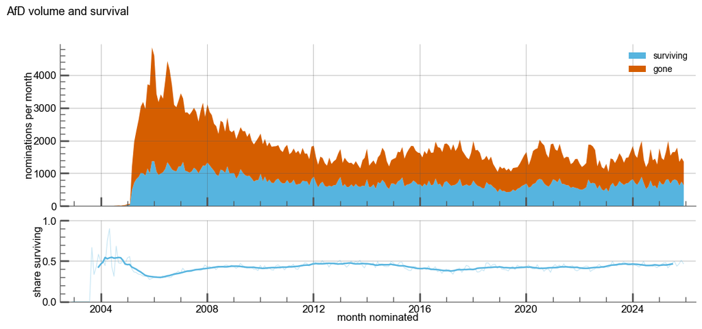

```python
fig, ax = plt.subplots(2, 1, figsize=(13, 6), sharex=True, height_ratios=[2, 1],
                       gridspec_kw=dict(hspace=.12))

monthly = (cases.assign(month=pd.to_datetime(cases.afd_month))
                .groupby(["month", "surviving"]).size().unstack(fill_value=0)
                .rename(columns={True: "surviving", False: "gone"})[["surviving", "gone"]])
monthly.plot.area(ax=ax[0], color=[COLORS["surviving"], COLORS["gone"]], lw=0)
ax[0].set(ylabel="nominations per month", xlabel="")
ax[0].legend(frameon=False)

rate = monthly.surviving / monthly.sum(axis=1)
ax[1].plot(rate.index, rate, alpha=.35, color=COLORS["surviving"], lw=.8)
ax[1].plot(rate.index, rate.rolling(12, center=True).mean(), color=COLORS["surviving"], lw=1.8)
ax[1].set(ylabel="share surviving", xlabel="month nominated", ylim=(0, 1))
fig.suptitle("AfD volume and survival", x=.06, ha="left", fontsize=13)
```

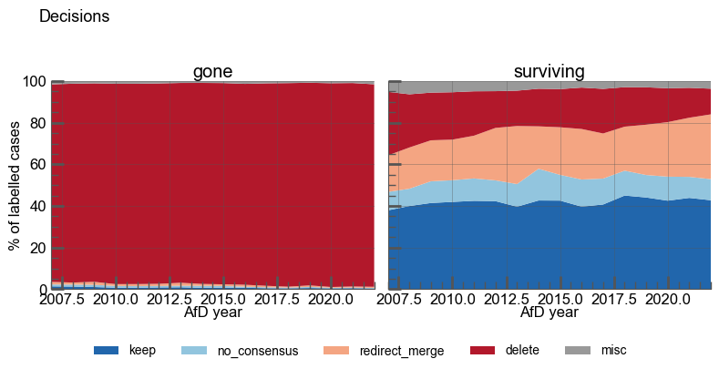

```python
# outcome mix by year, gone vs surviving
fig, ax = plt.subplots(1, 2, figsize=(8, 4), sharey=True, sharex=True)
for a, (g, title) in zip(ax, [("gone", "gone"), ("surviving", "surviving")]):
    d = panel(D, g)
    t = (pd.crosstab(d.afd_year, d.decision_flat, normalize="index").mul(100)
           .reindex(columns=DEC_ORDER, fill_value=0).fillna(0))
    a.stackplot(t.index.astype(float), *[t[c] for c in DEC_ORDER],
                labels=DEC_ORDER, colors=[DEC_COLORS[c] for c in DEC_ORDER])
    a.set(title=title, ylim=(0, 100), xlim=(t.index.min(), t.index.max()), xlabel="AfD year")
ax[0].set_ylabel("% of labelled cases")
fig.legend(*ax[0].get_legend_handles_labels(), loc="lower center", ncol=len(DEC_ORDER), frameon=False)
fig.suptitle("Decisions", x=.06, ha="left", fontsize=13)
fig.tight_layout(rect=[0, .09, 1, .95])
```

Note -

```
"keep": "keep",
"speedy_keep": "keep",

"delete": "delete",
"speedy_delete": "delete",
"soft_delete": "delete",

"no_consensus": "no_consensus",

"redirect": "redirect_merge",
"merge": "redirect_merge",

"withdrawn": "misc",
"procedural": "misc",
"draftify": "misc",
"transwiki": "misc",
"other": "misc"
# "unparsed" deliberately absent -> NaN
```

## 2. What a discussion looks like

- length
- duration
- latency
- participants

```python
def summary(cols, frame=None, groups=three):
    """median (IQR) per group, plus the sample/nonsample ratio -- the table to quote."""
    F = D if frame is None else frame
    out = {}
    for g in groups:
        x = F.pipe(panel, g)[cols]
        out[g] = (x.median().round(2).astype(str) + "  ("
                  + x.quantile(.25).round(2).astype(str) + "–"
                  + x.quantile(.75).round(2).astype(str) + ")")
    t = pd.DataFrame(out)
    t["sample / nonsample"] = (F.pipe(panel, "sample")[cols].median()
                               / F.pipe(panel, "surviving_nonsample")[cols].median()).round(2)
    return t

SHOW = HEADLINE + ["n_editors", "n_edits", "size_chars"]
summary(sorted(set(SHOW), key=SHOW.index))
```

|  | gone | sample | surviving_nonsample | sample / nonsample |
| --- | --- | --- | --- | --- |
| size_chars | 3013.0 (2272.0–4207.0) | 4667.0 (3331.0–7041.25) | 3977.0 (2808.0–6178.75) | 1.17 |
| dur_human_days | 7.23 (6.21–9.2) | 7.47 (6.1–15.04) | 7.52 (6.37–14.16) | 0.99 |
| lat_median_h | 8.63 (2.66–23.98) | 6.24 (2.19–16.59) | 6.7 (2.31–18.08) | 0.93 |
| n_discussants | 5.0 (3.0–6.0) | 6.0 (4.0–8.0) | 6.0 (4.0–8.0) | 1.00 |
| n_editors | 6.0 (5.0–8.0) | 8.0 (6.0–10.0) | 7.0 (6.0–10.0) | 1.14 |
| n_edits | 7.0 (5.0–10.0) | 10.0 (7.0–14.0) | 9.0 (6.0–13.0) | 1.11 |

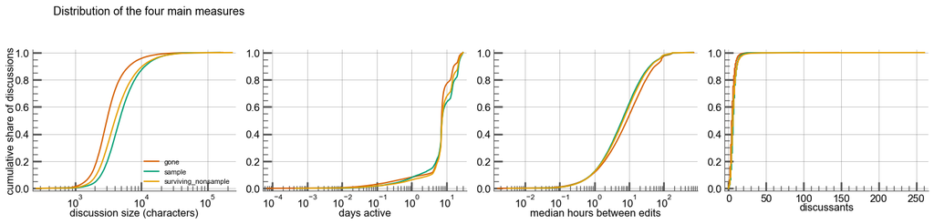

```python
fig, ax = plt.subplots(1, 4, figsize=(15, 3.6))
LAB = {"size_chars": "discussion size (characters)", "dur_human_days": "days active",
       "lat_median_h": "median hours between edits", "n_discussants": "discussants"}

for a, col in zip(ax, HEADLINE):
    for g in three:
        ecdf(a, panel(D, g)[col], label=g, color=COLORS[g], positive=col != "n_discussants")
    if col != "n_discussants":
        a.set_xscale("log")
    a.set(xlabel=LAB[col])
ax[0].set_ylabel("cumulative share of discussions")
ax[0].legend(frameon=False, fontsize=8)
fig.suptitle("Distribution of the four main measures", x=.06, ha="left", fontsize=13)
fig.tight_layout(rect=[0, 0, 1, .92])
```

```
cumulative % of human edits within N days of the nomination
```

```
      gone  sample  surviving_nonsample
1d    49.9    43.8                 45.5
3d    62.9    59.2                 60.9
7d    79.3    75.5                 78.1
14d   93.2    89.8                 91.7
21d   97.2    95.7                 96.5
30d   98.7    98.5                 98.6
60d   99.0    99.0                 99.0
90d   99.1    99.1                 99.0
365d  99.3    99.2                 99.2
```

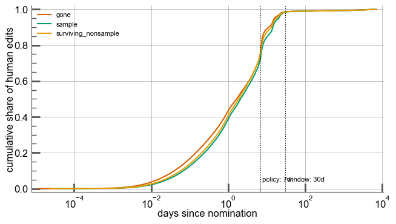

```python
# why the 30-day window: activity is almost entirely front-loaded
cuts = [1, 3, 7, 14, 21, 30, 60, 90, 365]
hg = h.join(D.grp, on="afd_pageid", how="inner")
print("cumulative % of human edits within N days of the nomination")
print(pd.DataFrame({g: {f"{c}d": 100 * (panel(hg, g).age <= c).mean() for c in cuts}
                    for g in three}).round(1).to_string())

fig, a = plt.subplots(figsize=(7.5, 4))
for g in three:
    ecdf(a, panel(hg, g).age, label=g, color=COLORS[g], positive=True)
for d, lab in ((7, "policy: 7d"), (WINDOW, f"window: {WINDOW}d")):
    a.axvline(d, color="k", lw=.8, ls=":")
    a.text(d, .04, f" {lab}", fontsize=8, color="k")
a.set(xscale="log", xlabel="days since nomination", ylabel="cumulative share of human edits")
a.legend(frameon=False, fontsize=8)
```

```python
# a random 10 discussions per group, to read by hand
from IPython.display import HTML, display

N_CASES, SEED = 10, 0
SHOW_C = ["case_title", "grp", "afd_year", "decision_flat"] + HEADLINE + ["n_editors", "discussion"]
C = D.join(cases.set_index("afd_pageid")[["case_title", "afd_discussion_url"]])
C["discussion"] = "https://en.wikipedia.org/wiki/" + C.afd_discussion_url

def show_cases(frame, col, levels, n=N_CASES, seed=SEED):
    """n random discussions per level of `col`, with a clickable link to each."""
    parts = []
    for k in levels:
        t = frame[frame[col].eq(k)]
        t = t.sample(min(n, len(t)), random_state=seed)[SHOW_C].sort_values("afd_year")
        parts.append(f"<h3>{k} ({len(frame[frame[col].eq(k)]):,} cases)</h3>"
                     + t.round(2).to_html(render_links=True, escape=True))
    display(HTML("\n".join(parts)))

show_cases(C, "grp", three)
```

gone (194,437 cases)

| afd_pageid | case_title | grp | afd_year | decision_flat | size_chars | dur_human_days | lat_median_h | n_discussants | n_editors | discussion |
| --- | --- | --- | --- | --- | --- | --- | --- | --- | --- | --- |
| 12522900 | University of Toronto student groups | gone | 2007.0 | delete | 2045.0 | 4.96 | 6.46 | 5.0 | 7.0 | https://en.wikipedia.org/wiki/Wikipedia:Articles_for_deletion/University_of_Toronto_student_groups |
| 23354890 | Jason Pierce (fighter) | gone | 2009.0 | redirect_merge | 4389.0 | 7.78 | 2.02 | 9.0 | 10.0 | https://en.wikipedia.org/wiki/Wikipedia:Articles_for_deletion/Jason_Pierce_(fighter) |
| 29000962 | Inventory +a | gone | 2010.0 | delete | 3375.0 | 2.56 | 0.74 | 8.0 | 10.0 | https://en.wikipedia.org/wiki/Wikipedia:Articles_for_deletion/Inventory_+a |
| 33886359 | The Football-Weekly | gone | 2011.0 | delete | 2847.0 | 13.18 | 9.95 | 8.0 | 8.0 | https://en.wikipedia.org/wiki/Wikipedia:Articles_for_deletion/The_Football-Weekly |
| 40697136 | The Dance Remixes | gone | 2013.0 | delete | 2248.0 | 8.19 | 23.14 | 2.0 | 4.0 | https://en.wikipedia.org/wiki/Wikipedia:Articles_for_deletion/The_Dance_Remixes |
| 40427551 | Sami Falioui | gone | 2013.0 | delete | 3466.0 | 7.35 | 19.87 | 5.0 | 6.0 | https://en.wikipedia.org/wiki/Wikipedia:Articles_for_deletion/Sami_Falioui |
| 52048297 | DMT THE Rapper (rapper) | gone | 2016.0 | delete | 4024.0 | 24.79 | 131.51 | 4.0 | 6.0 | https://en.wikipedia.org/wiki/Wikipedia:Articles_for_deletion/DMT_THE_Rapper_(rapper) |
| 55124894 | Alexandrea Yeo | gone | 2017.0 | delete | 4072.0 | 20.29 | 11.55 | 4.0 | 6.0 | https://en.wikipedia.org/wiki/Wikipedia:Articles_for_deletion/Alexandrea_Yeo |
| 67010110 | Seyed Morteza Sajjadi | gone | 2021.0 | delete | 2790.0 | 7.14 | 56.17 | 2.0 | 4.0 | https://en.wikipedia.org/wiki/Wikipedia:Articles_for_deletion/Seyed_Morteza_Sajjadi |
| 67551671 | Thomas Milo | gone | 2021.0 | delete | 6058.0 | 26.06 | 39.92 | 8.0 | 10.0 | https://en.wikipedia.org/wiki/Wikipedia:Articles_for_deletion/Thomas_Milo |

sample (37,596 cases)

| afd_pageid | case_title | grp | afd_year | decision_flat | size_chars | dur_human_days | lat_median_h | n_discussants | n_editors | discussion |
| --- | --- | --- | --- | --- | --- | --- | --- | --- | --- | --- |
| 27798100 | Brave (2012 film) | sample | 2010.0 | keep | 25070.0 | 7.00 | 1.75 | 19.0 | 20.0 | https://en.wikipedia.org/wiki/Wikipedia:Articles_for_deletion/Brave_(2012_film) |
| 30657088 | Rune Massing | sample | 2011.0 | keep | 3458.0 | 10.99 | 11.92 | 4.0 | 6.0 | https://en.wikipedia.org/wiki/Wikipedia:Articles_for_deletion/Rune_Massing |
| 34843350 | Michael Eysenck | sample | 2012.0 | misc | 3647.0 | 0.30 | 0.96 | 5.0 | 6.0 | https://en.wikipedia.org/wiki/Wikipedia:Articles_for_deletion/Michael_Eysenck |
| 39735610 | Hansell Arauz | sample | 2013.0 | misc | 3722.0 | 6.68 | 7.18 | 4.0 | 5.0 | https://en.wikipedia.org/wiki/Wikipedia:Articles_for_deletion/Hansell_Arauz |
| 41726059 | Sweep the Leg Johnny | sample | 2014.0 | keep | 3005.0 | 2.66 | 16.21 | 3.0 | 4.0 | https://en.wikipedia.org/wiki/Wikipedia:Articles_for_deletion/Sweep_the_Leg_Johnny |
| 55237709 | Dale Copeland | sample | 2017.0 | keep | 2361.0 | 6.77 | 21.66 | 4.0 | 6.0 | https://en.wikipedia.org/wiki/Wikipedia:Articles_for_deletion/Dale_Copeland |
| 57805447 | Alan Sabrosky | sample | 2018.0 | no_consensus | 35922.0 | 23.79 | 0.88 | 9.0 | 9.0 | https://en.wikipedia.org/wiki/Wikipedia:Articles_for_deletion/Alan_Sabrosky |
| 64221708 | 2020–21 United States network television schedule | sample | 2020.0 | keep | 8398.0 | 0.32 | 0.15 | 12.0 | 13.0 | https://en.wikipedia.org/wiki/Wikipedia:Articles_for_deletion/2020–21_United_States_network_television_schedule |
| 70503153 | Susie Shellenberger | sample | 2022.0 | keep | 5179.0 | 12.63 | 10.64 | 8.0 | 10.0 | https://en.wikipedia.org/wiki/Wikipedia:Articles_for_deletion/Susie_Shellenberger |
| 71980907 | Cross (2011 film) | sample | 2022.0 | keep | 3510.0 | 7.14 | 14.55 | 4.0 | 6.0 | https://en.wikipedia.org/wiki/Wikipedia:Articles_for_deletion/Cross_(2011_film) |

surviving_nonsample (104,659 cases)

| afd_pageid | case_title | grp | afd_year | decision_flat | size_chars | dur_human_days | lat_median_h | n_discussants | n_editors | discussion |
| --- | --- | --- | --- | --- | --- | --- | --- | --- | --- | --- |
| 16876522 | 16 Magazine | surviving_nonsample | 2008.0 | keep | 3967.0 | 4.62 | 1.67 | 5.0 | 7.0 | https://en.wikipedia.org/wiki/Wikipedia:Articles_for_deletion/16_Magazine |
| 17633264 | Total conversion | surviving_nonsample | 2008.0 | delete | 3378.0 | 13.59 | 9.97 | 6.0 | 8.0 | https://en.wikipedia.org/wiki/Wikipedia:Articles_for_deletion/Total_conversion |
| 20780855 | Abhas Joshi | surviving_nonsample | 2008.0 | delete | 4258.0 | 4.59 | 3.07 | 13.0 | 14.0 | https://en.wikipedia.org/wiki/Wikipedia:Articles_for_deletion/Abhas_Joshi |
| 23424845 | Jim Piccillo | surviving_nonsample | 2009.0 | delete | 7816.0 | 6.94 | 0.72 | 8.0 | 9.0 | https://en.wikipedia.org/wiki/Wikipedia:Articles_for_deletion/Jim_Piccillo |
| 29765496 | Apollo 18 (film) | surviving_nonsample | 2010.0 | keep | 5130.0 | 7.07 | 2.17 | 7.0 | 9.0 | https://en.wikipedia.org/wiki/Wikipedia:Articles_for_deletion/Apollo_18_(film) |
| 34809881 | Stippleit.com | surviving_nonsample | 2012.0 | keep | 13103.0 | 8.66 | 0.51 | 7.0 | 8.0 | https://en.wikipedia.org/wiki/Wikipedia:Articles_for_deletion/Stippleit.com |
| 39559887 | You Set Me Free (Angie Miller Song) | surviving_nonsample | 2013.0 | redirect_merge | 3115.0 | 7.25 | 24.68 | 5.0 | 7.0 | https://en.wikipedia.org/wiki/Wikipedia:Articles_for_deletion/You_Set_Me_Free_(Angie_Miller_Song) |
| 53552540 | John Francis Nash | surviving_nonsample | 2017.0 | keep | 5766.0 | 7.05 | 7.61 | 5.0 | 7.0 | https://en.wikipedia.org/wiki/Wikipedia:Articles_for_deletion/John_Francis_Nash |
| 67094726 | I Love Computer Art | surviving_nonsample | 2021.0 | delete | 5431.0 | 7.44 | 18.61 | 2.0 | 3.0 | https://en.wikipedia.org/wiki/Wikipedia:Articles_for_deletion/I_Love_Computer_Art |
| 67071247 | Yuri Sinitsa | surviving_nonsample | 2021.0 | redirect_merge | 3570.0 | 14.31 | 15.78 | 5.0 | 7.0 | https://en.wikipedia.org/wiki/Wikipedia:Articles_for_deletion/Yuri_Sinitsa |